# SQ 029

## Shared Qs (029)

#### Question

1. An [ellipse](https://en.wikipedia.org/wiki/Ellipse) is a set of points such that the total distance from (1) one focus to (2) the edge to (3) the other focus is constant for any point on the edge. The two foci ($F_1$ and $F_2$) are a distance $2c$ apart, and the total distance from $F_1$ to the edge to $F_2$ is a distance $2a$.

   Let’s consider the example below with foci at $(-6.3,0)$ and $(6.3,0)$ and a covertex at $(0, 6)$:

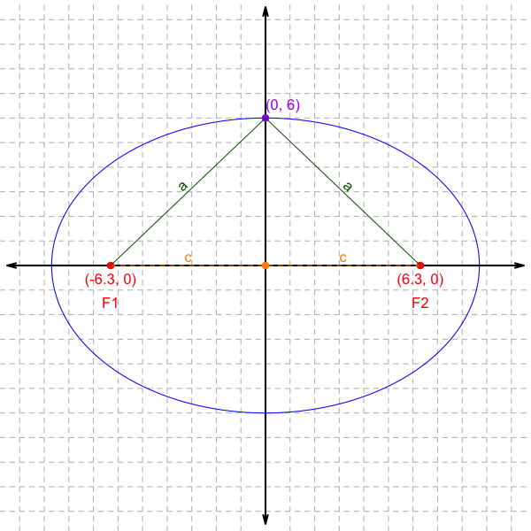

   Evaluate $2a$ and $2c$.
   - $a=$
   - $2a=$
   - $c=$
   - $2c=$

   Now, let’s pick another point on the ellipse, with (approximate) coordinates (4.7, 5.05):

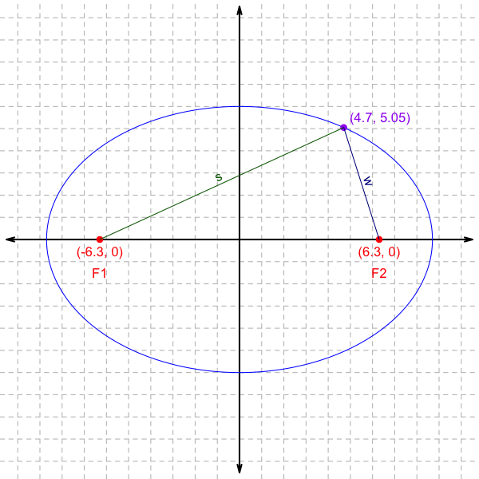

   The distance $s$ is from $F_1$ to the point on the edge. The distance $w$ is from $F_2$ to the point on the edge. Evaluate $s$, $w$, and the total distance ($s+w$).
   - $s=$
   - $w=$
   - $s+w=$

   Remember, the total distance when connecting
   1. The first focus $F_1$
   2. Any point on the edge
   3. The second focus $F_2$

   equals $2a$. Based on this information, find the location of the right vertex at ($x$, 0) in the diagram below.

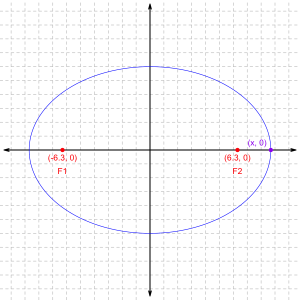

   - $x=$

#### Solution

#### Question

2. An [ellipse](https://en.wikipedia.org/wiki/Ellipse) is a set of points such that the total distance from (1) one focus to (2) the edge to (3) the other focus is constant for any point on the edge. The two foci ($F_1$ and $F_2$) are a distance $2c$ apart, and the total distance from $F_1$ to the edge to $F_2$ is a distance $2a$.

   Let’s consider the example below with foci at $(-4,0)$ and $(4,0)$ and a covertex at $(0, 4.2)$:

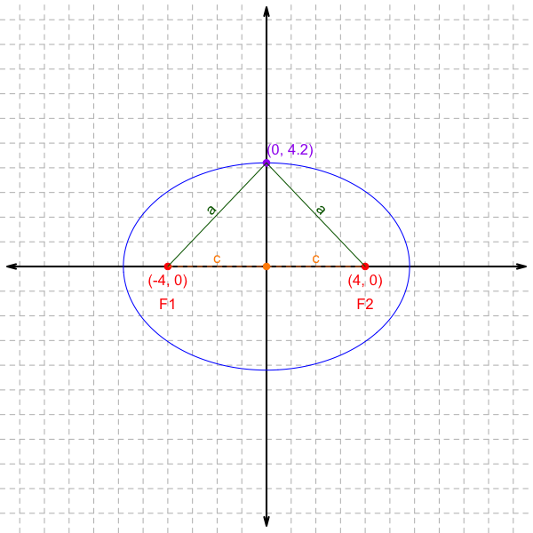

   Evaluate $2a$ and $2c$.
   - $a=$
   - $2a=$
   - $c=$
   - $2c=$

   Now, let’s pick another point on the ellipse, with (approximate) coordinates (4.21, 2.89):

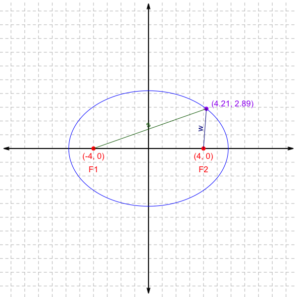

   The distance $s$ is from $F_1$ to the point on the edge. The distance $w$ is from $F_2$ to the point on the edge. Evaluate $s$, $w$, and the total distance ($s+w$).
   - $s=$
   - $w=$
   - $s+w=$

   Remember, the total distance when connecting
   1. The first focus $F_1$
   2. Any point on the edge
   3. The second focus $F_2$

   equals $2a$. Based on this information, find the location of the right vertex at ($x$, 0) in the diagram below.

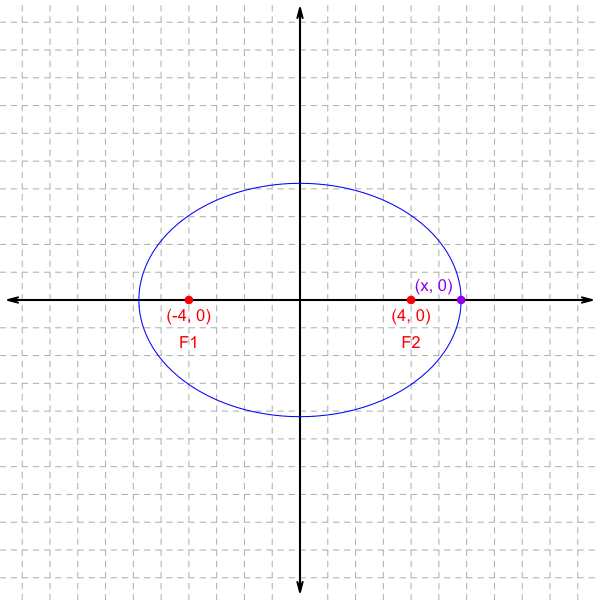

   - $x=$

#### Solution

#### Question

3. An [ellipse](https://en.wikipedia.org/wiki/Ellipse) is a set of points such that the total distance from (1) one focus to (2) the edge to (3) the other focus is constant for any point on the edge. The two foci ($F_1$ and $F_2$) are a distance $2c$ apart, and the total distance from $F_1$ to the edge to $F_2$ is a distance $2a$.

   Let’s consider the example below with foci at $(-3.6,0)$ and $(3.6,0)$ and a covertex at $(0, 7.7)$:

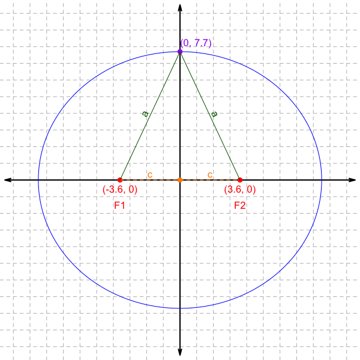

   Evaluate $2a$ and $2c$.
   - $a=$
   - $2a=$
   - $c=$
   - $2c=$

   Now, let’s pick another point on the ellipse, with (approximate) coordinates (7.31, 3.93):

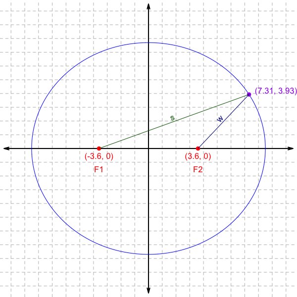

   The distance $s$ is from $F_1$ to the point on the edge. The distance $w$ is from $F_2$ to the point on the edge. Evaluate $s$, $w$, and the total distance ($s+w$).
   - $s=$
   - $w=$
   - $s+w=$

   Remember, the total distance when connecting
   1. The first focus $F_1$
   2. Any point on the edge
   3. The second focus $F_2$

   equals $2a$. Based on this information, find the location of the right vertex at ($x$, 0) in the diagram below.

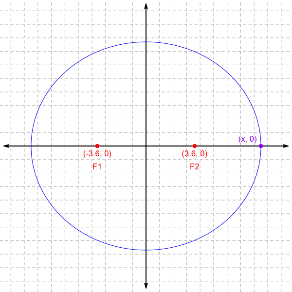

   - $x=$

#### Solution

#### Question

4. An [ellipse](https://en.wikipedia.org/wiki/Ellipse) is a set of points such that the total distance from (1) one focus to (2) the edge to (3) the other focus is constant for any point on the edge. The two foci ($F_1$ and $F_2$) are a distance $2c$ apart, and the total distance from $F_1$ to the edge to $F_2$ is a distance $2a$.

   Let’s consider the example below with foci at $(-1.1,0)$ and $(1.1,0)$ and a covertex at $(0, 6)$:

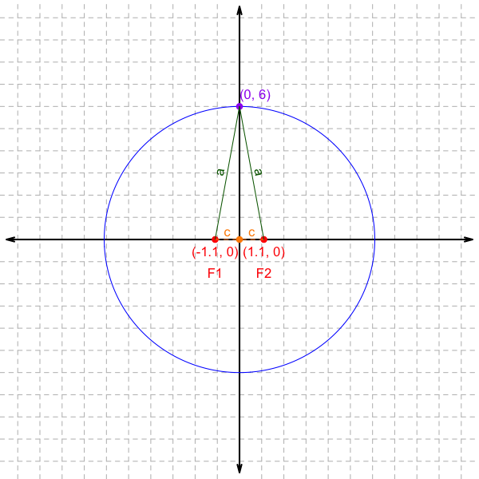

   Evaluate $2a$ and $2c$.
   - $a=$
   - $2a=$
   - $c=$
   - $2c=$

   Now, let’s pick another point on the ellipse, with (approximate) coordinates (5.53, 2.53):

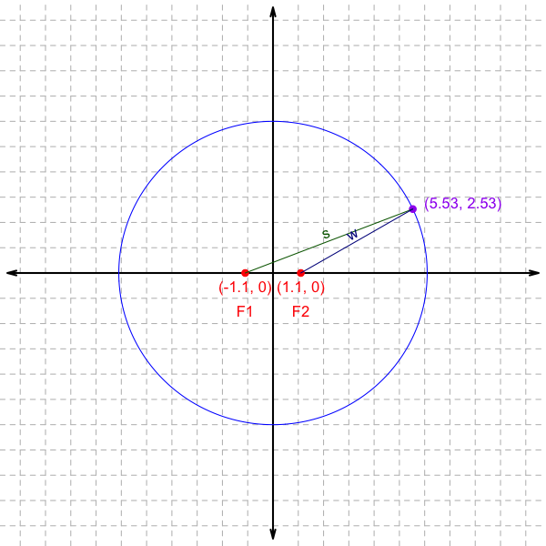

   The distance $s$ is from $F_1$ to the point on the edge. The distance $w$ is from $F_2$ to the point on the edge. Evaluate $s$, $w$, and the total distance ($s+w$).
   - $s=$
   - $w=$
   - $s+w=$

   Remember, the total distance when connecting
   1. The first focus $F_1$
   2. Any point on the edge
   3. The second focus $F_2$

   equals $2a$. Based on this information, find the location of the right vertex at ($x$, 0) in the diagram below.

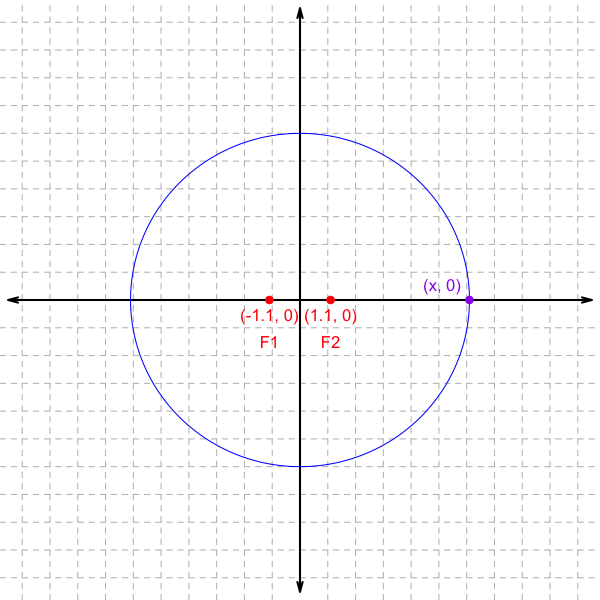

   - $x=$

#### Solution

#### Question

5. An [ellipse](https://en.wikipedia.org/wiki/Ellipse) is a set of points such that the total distance from (1) one focus to (2) the edge to (3) the other focus is constant for any point on the edge. The two foci ($F_1$ and $F_2$) are a distance $2c$ apart, and the total distance from $F_1$ to the edge to $F_2$ is a distance $2a$.

   Let’s consider the example below with foci at $(-4.2,0)$ and $(4.2,0)$ and a covertex at $(0, 4)$:

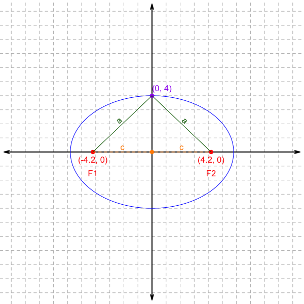

   Evaluate $2a$ and $2c$.
   - $a=$
   - $2a=$
   - $c=$
   - $2c=$

   Now, let’s pick another point on the ellipse, with (approximate) coordinates (3.17, 3.35):

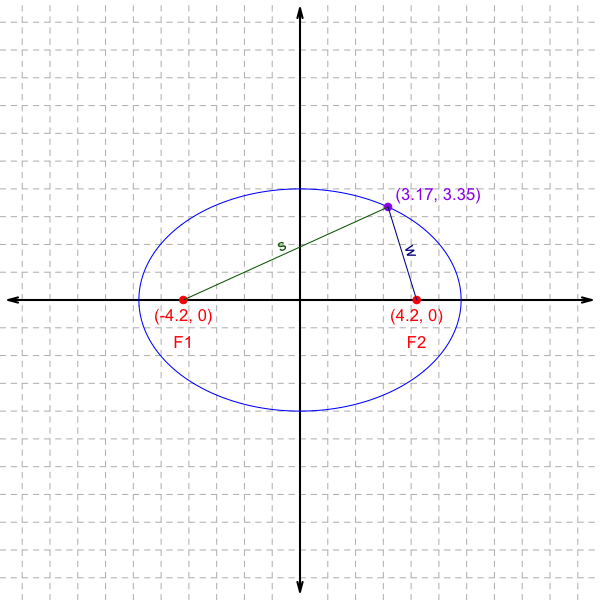

   The distance $s$ is from $F_1$ to the point on the edge. The distance $w$ is from $F_2$ to the point on the edge. Evaluate $s$, $w$, and the total distance ($s+w$).
   - $s=$
   - $w=$
   - $s+w=$

   Remember, the total distance when connecting
   1. The first focus $F_1$
   2. Any point on the edge
   3. The second focus $F_2$

   equals $2a$. Based on this information, find the location of the right vertex at ($x$, 0) in the diagram below.

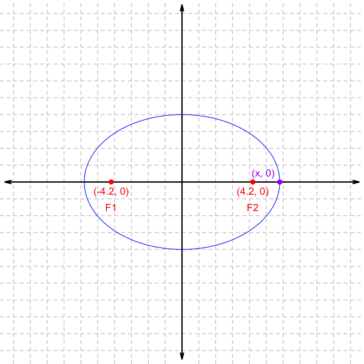

   - $x=$

#### Solution

#### Question

6. An [ellipse](https://en.wikipedia.org/wiki/Ellipse) is a set of points such that the total distance from (1) one focus to (2) the edge to (3) the other focus is constant for any point on the edge. The two foci ($F_1$ and $F_2$) are a distance $2c$ apart, and the total distance from $F_1$ to the edge to $F_2$ is a distance $2a$.

   Let’s consider the example below with foci at $(-2.8,0)$ and $(2.8,0)$ and a covertex at $(0, 4.5)$:

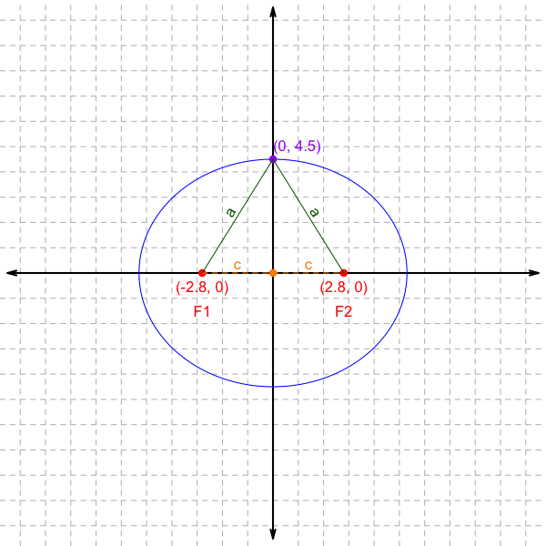

   Evaluate $2a$ and $2c$.
   - $a=$
   - $2a=$
   - $c=$
   - $2c=$

   Now, let’s pick another point on the ellipse, with (approximate) coordinates (3.6, 3.3):

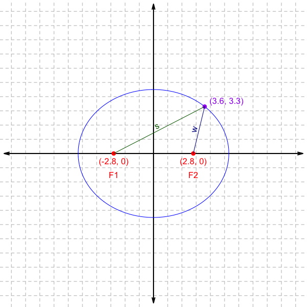

   The distance $s$ is from $F_1$ to the point on the edge. The distance $w$ is from $F_2$ to the point on the edge. Evaluate $s$, $w$, and the total distance ($s+w$).
   - $s=$
   - $w=$
   - $s+w=$

   Remember, the total distance when connecting
   1. The first focus $F_1$
   2. Any point on the edge
   3. The second focus $F_2$

   equals $2a$. Based on this information, find the location of the right vertex at ($x$, 0) in the diagram below.

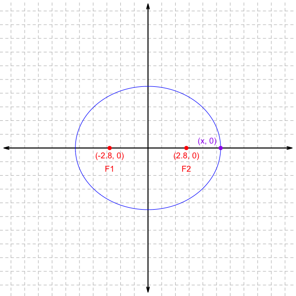

   - $x=$

#### Solution

#### Question

7. An [ellipse](https://en.wikipedia.org/wiki/Ellipse) is a set of points such that the total distance from (1) one focus to (2) the edge to (3) the other focus is constant for any point on the edge. The two foci ($F_1$ and $F_2$) are a distance $2c$ apart, and the total distance from $F_1$ to the edge to $F_2$ is a distance $2a$.

   Let’s consider the example below with foci at $(-2.1,0)$ and $(2.1,0)$ and a covertex at $(0, 7.2)$:

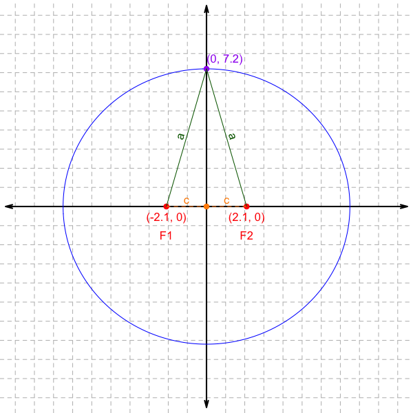

   Evaluate $2a$ and $2c$.
   - $a=$
   - $2a=$
   - $c=$
   - $2c=$

   Now, let’s pick another point on the ellipse, with (approximate) coordinates (4.3, 5.9):

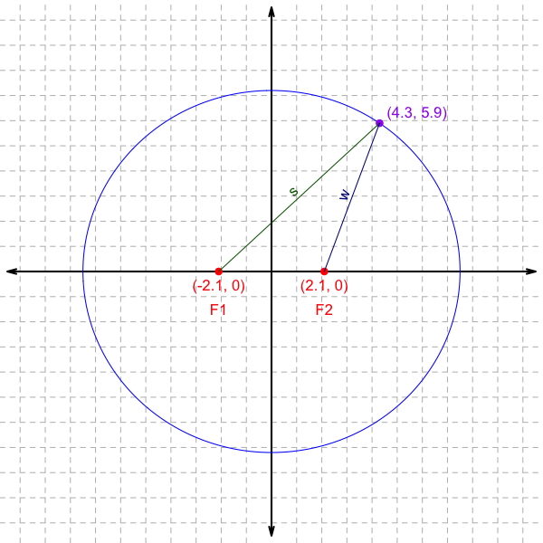

   The distance $s$ is from $F_1$ to the point on the edge. The distance $w$ is from $F_2$ to the point on the edge. Evaluate $s$, $w$, and the total distance ($s+w$).
   - $s=$
   - $w=$
   - $s+w=$

   Remember, the total distance when connecting
   1. The first focus $F_1$
   2. Any point on the edge
   3. The second focus $F_2$

   equals $2a$. Based on this information, find the location of the right vertex at ($x$, 0) in the diagram below.

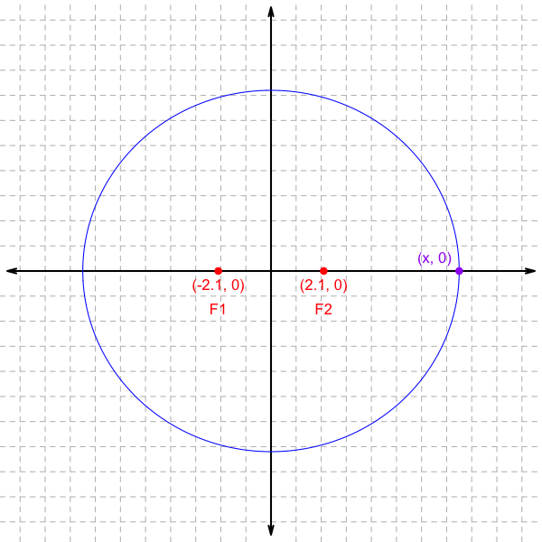

   - $x=$

#### Solution

#### Question

8. An [ellipse](https://en.wikipedia.org/wiki/Ellipse) is a set of points such that the total distance from (1) one focus to (2) the edge to (3) the other focus is constant for any point on the edge. The two foci ($F_1$ and $F_2$) are a distance $2c$ apart, and the total distance from $F_1$ to the edge to $F_2$ is a distance $2a$.

   Let’s consider the example below with foci at $(-4.5,0)$ and $(4.5,0)$ and a covertex at $(0, 2.8)$:

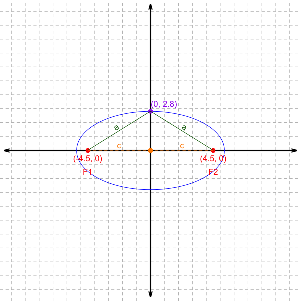

   Evaluate $2a$ and $2c$.
   - $a=$
   - $2a=$
   - $c=$
   - $2c=$

   Now, let’s pick another point on the ellipse, with (approximate) coordinates (4.59, 1.4):

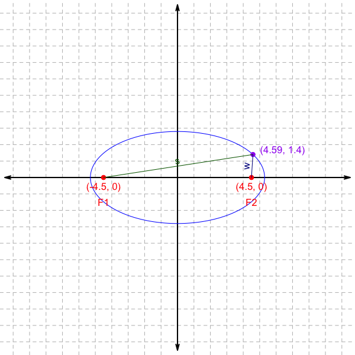

   The distance $s$ is from $F_1$ to the point on the edge. The distance $w$ is from $F_2$ to the point on the edge. Evaluate $s$, $w$, and the total distance ($s+w$).
   - $s=$
   - $w=$
   - $s+w=$

   Remember, the total distance when connecting
   1. The first focus $F_1$
   2. Any point on the edge
   3. The second focus $F_2$

   equals $2a$. Based on this information, find the location of the right vertex at ($x$, 0) in the diagram below.

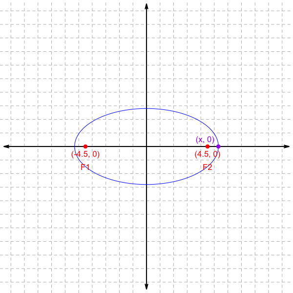

   - $x=$

#### Solution

#### Question

9. An [ellipse](https://en.wikipedia.org/wiki/Ellipse) is a set of points such that the total distance from (1) one focus to (2) the edge to (3) the other focus is constant for any point on the edge. The two foci ($F_1$ and $F_2$) are a distance $2c$ apart, and the total distance from $F_1$ to the edge to $F_2$ is a distance $2a$.

   Let’s consider the example below with foci at $(-6.5,0)$ and $(6.5,0)$ and a covertex at $(0, 7.2)$:

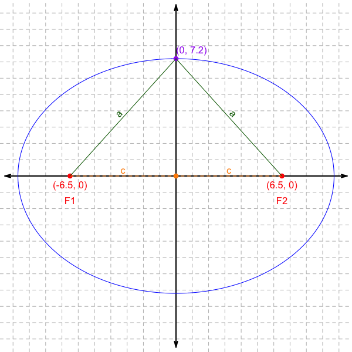

   Evaluate $2a$ and $2c$.
   - $a=$
   - $2a=$
   - $c=$
   - $2c=$

   Now, let’s pick another point on the ellipse, with (approximate) coordinates (8.96, 2.76):

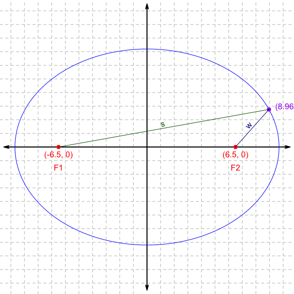

   The distance $s$ is from $F_1$ to the point on the edge. The distance $w$ is from $F_2$ to the point on the edge. Evaluate $s$, $w$, and the total distance ($s+w$).
   - $s=$
   - $w=$
   - $s+w=$

   Remember, the total distance when connecting
   1. The first focus $F_1$
   2. Any point on the edge
   3. The second focus $F_2$

   equals $2a$. Based on this information, find the location of the right vertex at ($x$, 0) in the diagram below.

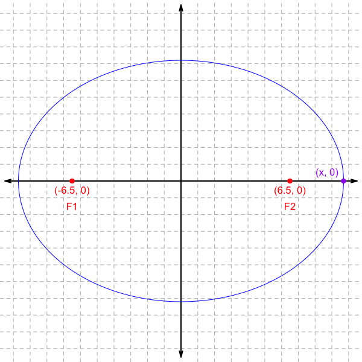

   - $x=$

#### Solution

#### Question

10. An [ellipse](https://en.wikipedia.org/wiki/Ellipse) is a set of points such that the total distance from (1) one focus to (2) the edge to (3) the other focus is constant for any point on the edge. The two foci ($F_1$ and $F_2$) are a distance $2c$ apart, and the total distance from $F_1$ to the edge to $F_2$ is a distance $2a$.

    Let’s consider the example below with foci at $(-2.8,0)$ and $(2.8,0)$ and a covertex at $(0, 9.6)$:

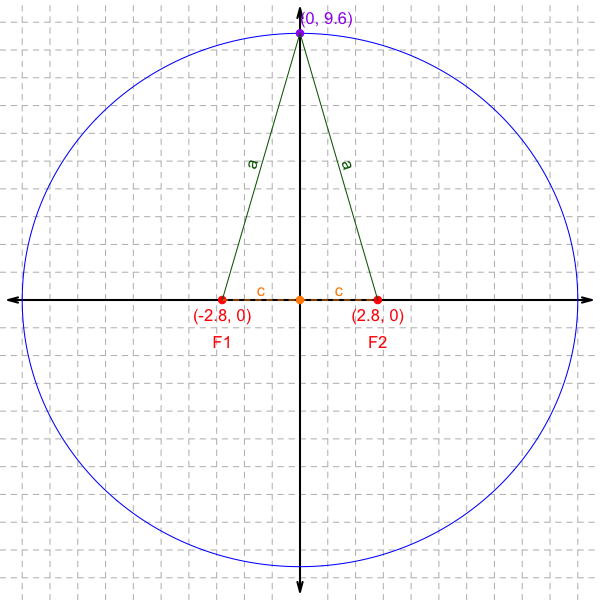

    Evaluate $2a$ and $2c$.
    - $a=$
    - $2a=$
    - $c=$
    - $2c=$

    Now, let’s pick another point on the ellipse, with (approximate) coordinates (4.99, 8.32):

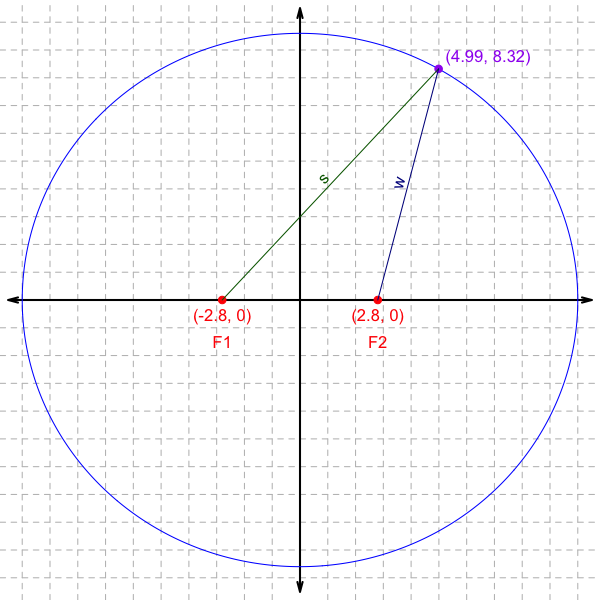

    The distance $s$ is from $F_1$ to the point on the edge. The distance $w$ is from $F_2$ to the point on the edge. Evaluate $s$, $w$, and the total distance ($s+w$).
    - $s=$
    - $w=$
    - $s+w=$

    Remember, the total distance when connecting
    1. The first focus $F_1$
    2. Any point on the edge
    3. The second focus $F_2$

    equals $2a$. Based on this information, find the location of the right vertex at ($x$, 0) in the diagram below.

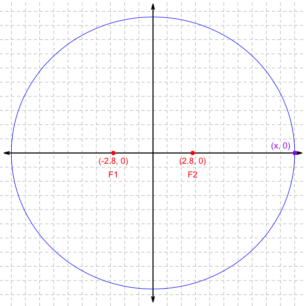

    - $x=$

#### Solution

#### Question

11. An [ellipse](https://en.wikipedia.org/wiki/Ellipse) is the set of ($x$, $y$) points that satisfy the equation below.

    $$\frac{(x-h)^2}{(r_1)^2}+\frac{(y-k)^2}{(r_2)^2}=1$$

    where the center is $(h,k)$, the horizontal radius is $r_1$, and the vertical radius is $r_2$.

    Determine the parameters of the ellipse in the graph below. You can assume all parameters are integers.

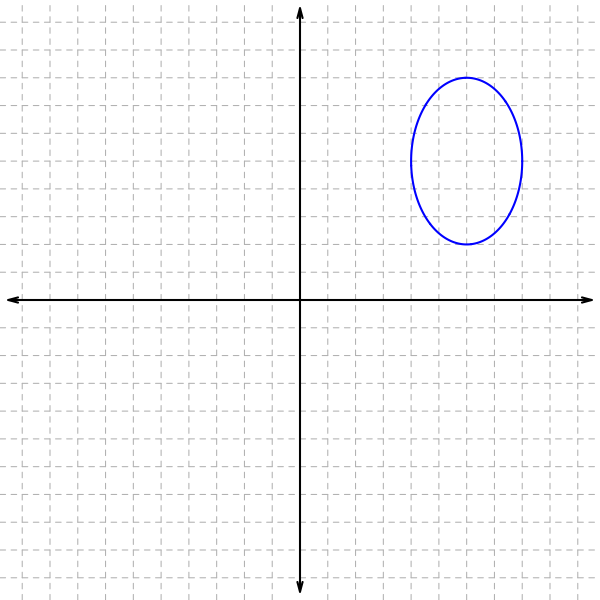

    - $h=$
    - $k=$
    - $r_1=$
    - $r_2=$

    Which of the following equations would give the graph above?

    $$\begin{align}
    A&:~~\frac{(x+5)^2}{4}+\frac{(y+6)^2}{9}=1 & B&:~~\frac{(x+5)^2}{4}+\frac{(y-6)^2}{9}=1 & C&:~~\frac{(x-5)^2}{4}+\frac{(y+6)^2}{9}=1 & D&:~~\frac{(x-5)^2}{4}+\frac{(y-6)^2}{9}=1 \\
    E&:~~\frac{(x+6)^2}{4}+\frac{(y+5)^2}{9}=1 & F&:~~\frac{(x+6)^2}{4}+\frac{(y-5)^2}{9}=1 & G&:~~\frac{(x-6)^2}{4}+\frac{(y+5)^2}{9}=1 & H&:~~\frac{(x-6)^2}{4}+\frac{(y-5)^2}{9}=1 \\
    I&:~~\frac{(x+5)^2}{9}+\frac{(y+6)^2}{4}=1 & J&:~~\frac{(x+5)^2}{9}+\frac{(y-6)^2}{4}=1 & K&:~~\frac{(x-5)^2}{9}+\frac{(y+6)^2}{4}=1 & L&:~~\frac{(x-5)^2}{9}+\frac{(y-6)^2}{4}=1 \\
    M&:~~\frac{(x+6)^2}{9}+\frac{(y+5)^2}{4}=1 & N&:~~\frac{(x+6)^2}{9}+\frac{(y-5)^2}{4}=1 & O&:~~\frac{(x-6)^2}{9}+\frac{(y+5)^2}{4}=1 & P&:~~\frac{(x-6)^2}{9}+\frac{(y-5)^2}{4}=1 \\
    \end{align}$$

    Equation

#### Solution

#### Question

12. An [ellipse](https://en.wikipedia.org/wiki/Ellipse) is the set of ($x$, $y$) points that satisfy the equation below.

    $$\frac{(x-h)^2}{(r_1)^2}+\frac{(y-k)^2}{(r_2)^2}=1$$

    where the center is $(h,k)$, the horizontal radius is $r_1$, and the vertical radius is $r_2$.

    Determine the parameters of the ellipse in the graph below. You can assume all parameters are integers.

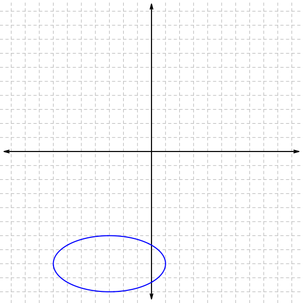

    - $h=$
    - $k=$
    - $r_1=$
    - $r_2=$

    Which of the following equations would give the graph above?

    $$\begin{align}
    A&:~~\frac{(x+3)^2}{4}+\frac{(y+8)^2}{16}=1 & B&:~~\frac{(x+3)^2}{4}+\frac{(y-8)^2}{16}=1 & C&:~~\frac{(x-3)^2}{4}+\frac{(y+8)^2}{16}=1 & D&:~~\frac{(x-3)^2}{4}+\frac{(y-8)^2}{16}=1 \\
    E&:~~\frac{(x+8)^2}{4}+\frac{(y+3)^2}{16}=1 & F&:~~\frac{(x+8)^2}{4}+\frac{(y-3)^2}{16}=1 & G&:~~\frac{(x-8)^2}{4}+\frac{(y+3)^2}{16}=1 & H&:~~\frac{(x-8)^2}{4}+\frac{(y-3)^2}{16}=1 \\
    I&:~~\frac{(x+3)^2}{16}+\frac{(y+8)^2}{4}=1 & J&:~~\frac{(x+3)^2}{16}+\frac{(y-8)^2}{4}=1 & K&:~~\frac{(x-3)^2}{16}+\frac{(y+8)^2}{4}=1 & L&:~~\frac{(x-3)^2}{16}+\frac{(y-8)^2}{4}=1 \\
    M&:~~\frac{(x+8)^2}{16}+\frac{(y+3)^2}{4}=1 & N&:~~\frac{(x+8)^2}{16}+\frac{(y-3)^2}{4}=1 & O&:~~\frac{(x-8)^2}{16}+\frac{(y+3)^2}{4}=1 & P&:~~\frac{(x-8)^2}{16}+\frac{(y-3)^2}{4}=1 \\
    \end{align}$$

    Equation